# Frequentist Fixed-effects Meta Regression

- Show All Code
- Hide All Code
- View Source

Author

Ananda Biswas

Published

November 4, 2026

## Required Libraries

**Show/Hide Code**

```r
library(openxlsx)

library(gt)
library(tidyverse)

library(metafor)
```

## Loading Data

**Show/Hide Code**

```r
df1 <- read.xlsx(data.path, sheet = 1)

df2 <- df1[1:14, ]
```

## Initial Sanity Checks

**Show/Hide Code**

```r
str(df2)
```

```
'data.frame':   14 obs. of  11 variables:
 $ Study            : chr  "Study.1" "Study.2" "Study.3" "Study.4" ...
 $ Sample.n1        : num  133 95 128 272 107 152 44 133 135 90 ...
 $ Sample.n2        : num  136 95 124 264 112 154 44 148 136 88 ...
 $ Follow-.up.months: num  97 72 71 80 199 78 59 156 74 145 ...
 $ HR.OS            : num  0.84 0.51 0.6 0.82 0.93 0.85 0.55 0.85 0.98 0.74 ...
 $ OS.ln.HR         : num  -0.17 -0.67 -0.51 -0.2 -0.07 -0.16 -0.6 -0.16 -0.02 -0.3 ...
 $ OS.se            : num  0.16 0.29 0.34 0.22 0.15 0.15 0.26 0.15 0.17 0.17 ...
 $ HR.DFS           : num  0.83 0.49 0.62 0.79 0.88 0.76 0.55 0.87 0.9 0.73 ...
 $ DFS.ln.HR        : num  -0.19 -0.71 -0.48 -0.24 -0.13 -0.27 -0.6 -0.14 -0.11 -0.31 ...
 $ DFS.se           : num  0.16 0.27 0.32 0.21 0.15 0.15 0.25 0.15 0.16 0.17 ...
 $ Non.prop         : chr  "0" "0" "0" "0" ...
```

**Show/Hide Code**

```r
dim(df2)
```

```
[1] 14 11
```

Snapshot of Gastric Cancer Data

| Study | Sample.n1 | Sample.n2 | Follow-.up.months | HR.OS | OS.ln.HR | OS.se | HR.DFS | DFS.ln.HR | DFS.se | Non.prop |
| --- | --- | --- | --- | --- | --- | --- | --- | --- | --- | --- |
| Study.1 | 133 | 136 | 97 | 0.84 | -0.17 | 0.16 | 0.83 | -0.19 | 0.16 | 0 |
| Study.2 | 95 | 95 | 72 | 0.51 | -0.67 | 0.29 | 0.49 | -0.71 | 0.27 | 0 |
| Study.3 | 128 | 124 | 71 | 0.60 | -0.51 | 0.34 | 0.62 | -0.48 | 0.32 | 0 |
| Study.4 | 272 | 264 | 80 | 0.82 | -0.20 | 0.22 | 0.79 | -0.24 | 0.21 | 0 |
| Study.5 | 107 | 112 | 199 | 0.93 | -0.07 | 0.15 | 0.88 | -0.13 | 0.15 | 0 |
| Study.6 | 152 | 154 | 78 | 0.85 | -0.16 | 0.15 | 0.76 | -0.27 | 0.15 | 0 |

## Derived Quantities

**Show/Hide Code**

```r
df2$weight <- 1 / (df2$OS.se)^2
```

## Generating Treatment Effect on Surrogate Endpoint in New Trials

**Show/Hide Code**

```r
range(df2$HR.DFS)
```

```
[1] 0.49 1.05
```

**Show/Hide Code**

```r
# Suppose 1000 new trials reporting TE on surrogate endpoint only
new.data <- data.frame(DFS.ln.HR = log(seq(0.45, 1.2, length=1000)))
```

## Model

Meta-regression is an extension of meta-analysis that includes the surrogate endpoint as a study-level covariate. The model is written as

$$\widehat{\theta}_i
=
\theta+\beta\widehat{\alpha}_i+\varepsilon_i,
\qquad
i=1,\ldots,N,$$

where

$$\varepsilon_i
\overset{\mathrm{iid}}{\sim}
N(0,\sigma^2).$$
Here:

- $\widehat{\theta}_i$ = estimated treatment effect on the final endpoint in study $i$;
- $\widehat{\alpha}_i$ = estimated treatment effect on the surrogate endpoint in study $i$;
- $\theta$ = intercept;
- $\beta$ = regression coefficient describing the association between surrogate and final treatment effects.

Here we assume that $\theta$ is common for all studies and the only reason observed treatment effect $\widehat{\theta_i}$’s are different from $\theta$ is the sampling error (in addition to the observed treatment effect on surrogate endpoint of that study).

## Model Fitting

**Show/Hide Code**

```r
fit.FEMR <- metafor::rma(OS.ln.HR ~ 1 + DFS.ln.HR, sei = OS.se, data = df2, method = "FE")
summary(fit.FEMR)
```

```
Fixed-Effects with Moderators Model (k = 14)

  logLik  deviance       AIC       BIC      AICc
  9.7954    0.6843  -15.5907  -14.3126  -14.4998

I^2 (residual heterogeneity / unaccounted variability): 0.00%
H^2 (unaccounted variability / sampling variability):   0.06
R^2 (amount of heterogeneity accounted for):            93.54%

Test for Residual Heterogeneity:
QE(df = 12) = 0.6843, p-val = 1.0000

Test of Moderators (coefficient 2):
QM(df = 1) = 10.7861, p-val = 0.0010

Model Results:

           estimate      se    zval    pval    ci.lb   ci.ub
intrcpt      0.0465  0.0774  0.6009  0.5479  -0.1052  0.1982
DFS.ln.HR    1.0237  0.3117  3.2842  0.0010   0.4128  1.6347  **

---
Signif. codes:  0 '***' 0.001 '**' 0.01 '*' 0.05 '.' 0.1 ' ' 1
```

## Prediction of TE on Clinical Outcome in New Trials and Confidence Intervals

We assume that there is no between-trial heterogeneity in either the target or the surrogate endpoint (fixed-effects assumption). So confidence intervals can be interpreted as prediction intervals.

**Show/Hide Code**

```r
FEMR.ci <- data.frame(predict(fit.FEMR, new.data$DFS.ln.HR))
head(FEMR.ci) |>
  gt()
```

| pred | se | ci.lb | ci.ub |
| --- | --- | --- | --- |
| -0.7709615 | 0.1953021 | -1.153747 | -0.3881764 |
| -0.7692550 | 0.1947992 | -1.151054 | -0.3874555 |
| -0.7675513 | 0.1942972 | -1.148367 | -0.3867357 |
| -0.7658505 | 0.1937962 | -1.145684 | -0.3860170 |
| -0.7641524 | 0.1932960 | -1.143006 | -0.3852992 |
| -0.7624572 | 0.1927968 | -1.140332 | -0.3845825 |

**Show/Hide Code**

```r
FEMR.ci$HR.OS <- exp(FEMR.ci$pred)
FEMR.ci$HR.DFS <- exp(new.data$DFS.ln.HR)

head(FEMR.ci) |>
  gt()
```

| pred | se | ci.lb | ci.ub | HR.OS | HR.DFS |
| --- | --- | --- | --- | --- | --- |
| -0.7709615 | 0.1953021 | -1.153747 | -0.3881764 | 0.4625681 | 0.4500000 |
| -0.7692550 | 0.1947992 | -1.151054 | -0.3874555 | 0.4633581 | 0.4507508 |
| -0.7675513 | 0.1942972 | -1.148367 | -0.3867357 | 0.4641482 | 0.4515015 |
| -0.7658505 | 0.1937962 | -1.145684 | -0.3860170 | 0.4649384 | 0.4522523 |
| -0.7641524 | 0.1932960 | -1.143006 | -0.3852992 | 0.4657285 | 0.4530030 |
| -0.7624572 | 0.1927968 | -1.140332 | -0.3845825 | 0.4665187 | 0.4537538 |

## Trial-level Association Plot

**Show/Hide Code**

```r
FEMR.association.plot <- ggplot(df2, aes(x = HR.DFS, y = HR.OS)) +
  geom_ribbon(aes(x = HR.DFS, ymin = exp(ci.lb), ymax = exp(ci.ub)), data = FEMR.ci, fill = "steelblue", alpha = 0.4) +
  geom_smooth(aes(x = HR.DFS, y = HR.OS), data = FEMR.ci, stat = 'identity') +
  geom_point(aes(size = weight), shape = 21, col = "gray30", fill = "orange") +
  scale_x_continuous(transform = "log",
                     limits = c(0.45, 1.2),
                     breaks=c(0.5,0.6,0.7,0.8,0.9,1,1.1),
                     expand = c(0.01, 0.01)) +
  scale_y_continuous(transform = "log",
                     limits = c(0.3, 1.7),
                     breaks=c(0.3,0.4,0.5,0.7,1,1.2,1.5),
                     expand = c(0.01, 0.01)) +
  geom_hline(yintercept = 1, linetype = 'dashed') +
  xlab("Disease-free survival hazard ratio (log scale)")+
  ylab(paste("Overall survival hazard ratio" , "\n", "\U00B1", "95% confidence and prediction intervals (log scale)")) +
  ggtitle("Frequentist Fixed-effects Meta-regression") +
  theme_bw() +
  scale_colour_hue("trial") +
  theme(legend.position = "none")
```

**Show/Hide Code**

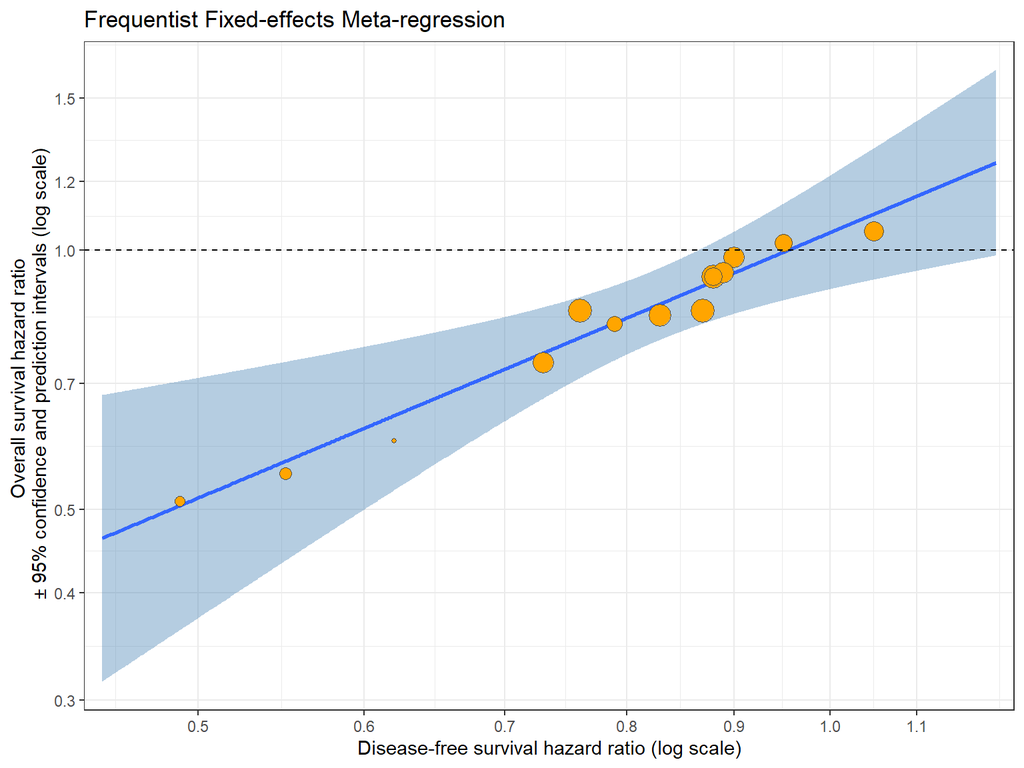

```r
FEMR.association.plot
```

## Surrogate Threshold Effect

**Show/Hide Code**

```r
candidate.HR.DFS <- FEMR.ci %>%
  filter(ci.ub < 0) %>%
  pull(HR.DFS)

FEMR.STE <- round(max(candidate.HR.DFS), digits = 3)
FEMR.STE
```

```
[1] 0.866
```

## Leave-one-out Cross-validation

Leave-one-out cross-validation (LOOCV) is performed by selecting each trial in a data set in turns and using it as the validation set while using the rest $(n-1)$ of the trials as the training set. This is repeated $n$ times. For each iteration in the LOOCV procedure, models are ﬁtted to the training set, and the dependent variable of interest (target endpoint) is predicted on the basis of the explanatory variable(s) in the models (surrogate endpoint) in the validation set.

Two different criteria were used to assess the performance of each model for each iteration of the LOOCV. For each criterion, the median and range of the output values were used to assess model performance.

### Proportion of actual values from the validation set that lies within the 95% prediction interval from the training set

The steps are as follows:

- Leave out $i-$th study and train the model with remaining $n - 1$ studies.
- Obtain $95\%$ prediction interval for the treatment effect on target endpoint (OS) in the left-out trial, using its surrogate endpoint (DFS) treatment effect.
- Simulate $1000$ OS treatment effects based on normal distribution using the observed OS treatment effect and its standard error from the left-out trial.
- Calculate the proportion of the $1000$ simulated values falling within the prediction interval, $p_i$.
- Repeat these steps for all the studies, leaving out one at a time.
- Calculate $median(p_1, \ldots, p_n)$ and $range(p_1, \ldots, p_n)$.

**Show/Hide Code**

```r
n <- nrow(df2)

prop <- c()

absolute.difference <- c()
```

**Show/Hide Code**

```r
for(i in 1:n){
  df <- df2[-i,]

  fit <- metafor::rma(OS.ln.HR ~ 1 + DFS.ln.HR, sei = OS.se, data = df, method = "FE")

  new.data <- data.frame(DFS.ln.HR = df2$DFS.ln.HR[i])

  FEMR.ci <- data.frame(predict(fit, new.data$DFS.ln.HR))

  # for criterion 1
  simulated.OS.ln.HR <- rnorm(1000, mean = df2$OS.ln.HR[i], sd = df2$OS.se[i])

  prop[i] <- mean((simulated.OS.ln.HR >= FEMR.ci$ci.lb) & (simulated.OS.ln.HR <= FEMR.ci$ci.ub))

  # for criterion 2
  absolute.difference[i] <- abs(df2$OS.ln.HR[i] - FEMR.ci$pred)
}
```

**Show/Hide Code**

```r
median.prop <- median(prop)
median.prop
```

```
[1] 0.481
```

**Show/Hide Code**

```r
range.prop <- range(prop)
range.prop
```

```
[1] 0.373 0.832
```

### Absolute difference between mean predicted value and actual value

The absolute difference between the actual log hazard ratio and the predicted log hazard ratio for OS for each trial left out will be recorded.

**Show/Hide Code**

```r
median.absolute.difference <- median(absolute.difference)
median.absolute.difference |> round(3)
```

```
[1] 0.031
```

**Show/Hide Code**

```r
range.absolute.difference <- range(absolute.difference)
range.absolute.difference |> round(3)
```

```
[1] 0.001 0.081
```